# Travaux Pratiques : Regression Lineaire, Regression Logistique

## 2-La régression logistique

### Les bibliothèques requises

Tout d'abord, nous allons importer les bibliothèques requises

```python
import pandas as pd
import numpy as np
import matplotlib.pyplot as plt
import seaborn as sns
from sklearn import preprocessing
from sklearn.linear_model import LogisticRegression
from sklearn.model_selection import train_test_split
from sklearn.preprocessing import StandardScaler
from sklearn import metrics
```

### Charger le jeu de données

J'ai utiliser les données de régression logit fournies par UCLA (Institut de recherche et d'éducation numériques).

```python
dataset = pd.read_csv('binary.csv')
```

```python
dataset.columns = ["admit", "gre", "gpa", "prestige"]
```

admit: l'etudiant admit ou non gre:Le Graduate Record Examination (GRE) est un test en anglais créé et géré par l'entreprise ETS. Ce test est requis pour étudier dans la plupart des universités ou graduate schools dans des pays anglophones. gpa:C'est un moyen standard de mesurer les résultats scolaires aux États-Unis. prestige:niveaux d'études

```python
dataset.shape
```

```
(400, 4)
```

```python
dataset.head()
```

|  | admit | gre | gpa | prestige |
| --- | --- | --- | --- | --- |
| 0 | 0 | 380 | 3.61 | 3 |
| 1 | 1 | 660 | 3.67 | 3 |
| 2 | 1 | 800 | 4.00 | 1 |
| 3 | 1 | 640 | 3.19 | 4 |
| 4 | 0 | 520 | 2.93 | 4 |

Représentons toutes les colonnes du jeu de données.

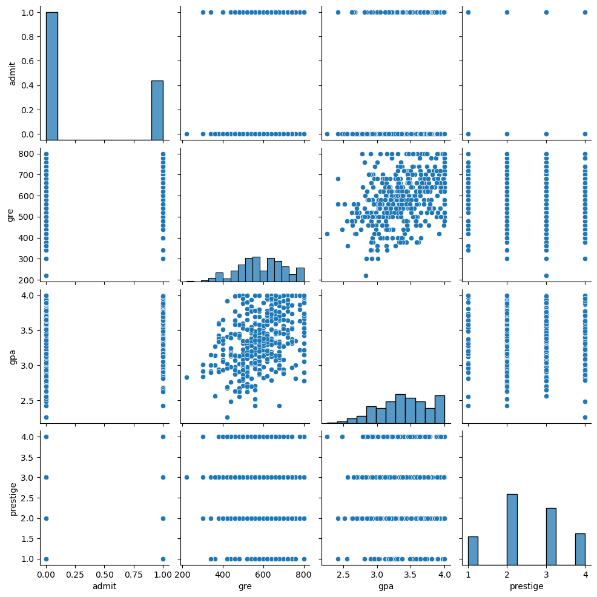

```python
%matplotlib inline
sns.pairplot(dataset)
```

### Prétraitement des données

Une fois les données chargées, il est recommandé de vérifier s’il existe des valeurs manquantes dans les données. Nous comptons le nombre de valeurs manquantes pour chaque fonctionnalité à l'aide deisnull()

```python
dataset.isnull ().sum ()
```

```
admit       0
gre         0
gpa         0
prestige    0
dtype: int64
```

il ne manque aucune valeur dans cet ensemble de données La bibliothèque Python pandas offre une grande flexibilité dans la manière dont les variables catégorielles sont représentées.

```python
dummy_ranks = pd.get_dummies(dataset['prestige'], prefix='prestige')
```

```python
dummy_ranks.head()
```

|  | prestige_1 | prestige_2 | prestige_3 | prestige_4 |
| --- | --- | --- | --- | --- |
| 0 | False | False | True | False |
| 1 | False | False | True | False |
| 2 | True | False | False | False |
| 3 | False | False | False | True |
| 4 | False | False | False | True |

Création d'une data prés à la régression

```python
a=['admit', 'gre', 'gpa']
data = dataset[a].join(dummy_ranks.iloc[:,:])
```

```python
data['admit'].value_counts()
```

```
admit
0    273
1    127
Name: count, dtype: int64
```

### Fractionnement des données en ensembles de traitement et de test

```python
x = data.drop('admit', axis=1)
y = data['admit']
x_train, x_test, y_train, y_test = train_test_split(x, y, test_size=0.3, random_state=1)
```

Nous allons maintenant procéder à une régression logistique, ce qui est assez simple. Nous spécifions simplement la colonne contenant la variable que nous essayons de prédire, suivie des colonnes que le modèle devrait utiliser pour effectuer la prédiction. Nous prévoyons maintenant la colonne d'admission en fonction des variables nominales gre, gpa et prestige_1, prestige_2, prestige_3 et prestige_4.

### Génération du modèle

```python
logmodel = LogisticRegression(C=1e20)
logmodel.fit(x_train, y_train)
```

```
LogisticRegression(C=1e+20)
```

### Modèle obtenu

```python
logmodel.intercept_, logmodel.coef_
```

```
(array([-3.6342291]),
 array([[ 0.00164044,  0.80640592, -0.16998552, -0.59350372, -1.29273024,
         -1.57800961]]))
```

### Évaluation du modèle

```python
y_pred = logmodel.predict(x_test)
y_pred
```

```
array([0, 0, 0, 0, 0, 0, 0, 0, 0, 0, 0, 0, 0, 0, 0, 0, 0, 0, 0, 0, 0, 0,
       0, 0, 0, 1, 0, 0, 0, 1, 0, 0, 1, 0, 0, 0, 0, 0, 0, 1, 0, 1, 0, 0,
       0, 0, 0, 0, 0, 0, 0, 0, 0, 1, 0, 1, 0, 0, 0, 1, 0, 0, 1, 0, 0, 0,
       1, 0, 1, 0, 0, 0, 1, 0, 0, 0, 0, 0, 0, 0, 0, 0, 0, 0, 1, 0, 0, 0,
       0, 0, 0, 0, 0, 0, 0, 0, 1, 0, 0, 0, 0, 0, 0, 0, 1, 0, 0, 0, 0, 0,
       0, 1, 0, 0, 0, 1, 0, 0, 0, 1])
```

```python
count_misclassified = (y_test != y_pred).sum()
print('Échantillons mal classés: {}'.format(count_misclassified))
accuracy = metrics.accuracy_score(y_test, y_pred)
print('Précision: {:.2f}'.format(accuracy))
```

```
Échantillons mal classés: 30
Précision: 0.75
```